# chapter 1

Harrison Linder

2024-01-19

below are the necessary libraries to use for this course

```r
library(tidyverse)
library(tidycensus)
library(sf)
library(kableExtra)
options(scipen=999)
options(tigris_class = "sf")

# the below line was changed from the code provided in the book. the operator giver was "=", however that appeared to not save "root.dir" to the environment, so I chaged the operator to "<-"

root.dir <- "https://raw.githubusercontent.com/urbanSpatial/Public-Policy-Analytics-Landing/master/DATA/"
source("https://raw.githubusercontent.com/urbanSpatial/Public-Policy-Analytics-Landing/master/functions.r")
```

Here is the color palette we are going to use for maps

```r
palette5 <- c("#f0f9e8","#bae4bc","#7bccc4","#43a2ca","#0868ac")
```

how to install my census api key

```r
census_api_key("c08e727b3d32b823955aea424744c9dda3b30df0", install = TRUE, overwrite = TRUE)
```

```
## Your original .Renviron will be backed up and stored in your R HOME directory if needed.
```

```
## Your API key has been stored in your .Renviron and can be accessed by Sys.getenv("CENSUS_API_KEY").
## To use now, restart R or run `readRenviron("~/.Renviron")`
```

```
## [1] "c08e727b3d32b823955aea424744c9dda3b30df0"
```

```r
# readRenviron("~/.Renviron") is for some reason needed for the api to be active in the current session
readRenviron("~/.Renviron")
```

we will be using the following data

from the textbook: In this chapter, the tidycensus is used to query and return Census data directly into R. At the time of publication however, the Census has disabled the year 2000 endpoint/data.10 Instead, the code below downloads an equivalent data frame called tracts00. A data frame is the most common way to store data in R. The code block at the end of this section demonstrates a tidycensus call to return 2017 data.

```r
tracts00 <-
  st_read(file.path(root.dir,"/Chapter1/PHL_CT00.geojson")) %>%
    st_transform('ESRI:102728')
tracts00[1:3,]
```

```
## Simple feature collection with 3 features and 4 fields
## Geometry type: MULTIPOLYGON
## Dimension:     XY
## Bounding box:  xmin: 2696968 ymin: -68663.64 xmax: 2700290 ymax: -65640.25
## Projected CRS: NAD_1983_StatePlane_Pennsylvania_North_FIPS_3701_Feet
##         GEOID           NAME  variable value                       geometry
## 1 42101000100 Census Tract 1   P001001  2576 MULTIPOLYGON (((2697812 -65...
## 2 42101000100 Census Tract 1   P006002  2095 MULTIPOLYGON (((2697812 -65...
## 3 42101000100 Census Tract 1 PCT025050    48 MULTIPOLYGON (((2697812 -65...
```

to find out how many census plots we have in our geography (Philadelphia), we can create a table the displays how many rows we have by variable. our data is long formatted so there are multiple rows representing a given census plot.

```r
table(tracts00$variable)
```

```
##
##   H056001   P001001   P006002   P053001   P092001 PCT025009 PCT025050
##       381       381       381       381       381       381       381
```

now we are going to plot population by census plot in the year 2000. To do that, we are going to create a variable the has filtered for only rows where the variable is that representing population in the year 2000.

```r
totalpop00 <-
    tracts00 %>%
    filter(variable == "P001001")
#lets make sure we have the correct number of rows (381)
nrow(totalpop00)
```

```
## [1] 381
```

```r
# lets see a snapshot of our data
head(totalpop00)
```

```
## Simple feature collection with 6 features and 4 fields
## Geometry type: MULTIPOLYGON
## Dimension:     XY
## Bounding box:  xmin: 2688965 ymin: -68894.43 xmax: 2700290 ymax: -64443.03
## Projected CRS: NAD_1983_StatePlane_Pennsylvania_North_FIPS_3701_Feet
##         GEOID           NAME variable value                       geometry
## 1 42101000100 Census Tract 1  P001001  2576 MULTIPOLYGON (((2697812 -65...
## 2 42101000200 Census Tract 2  P001001  1355 MULTIPOLYGON (((2696038 -65...
## 3 42101000300 Census Tract 3  P001001  2577 MULTIPOLYGON (((2690929 -64...
## 4 42101000400 Census Tract 4  P001001  4387 MULTIPOLYGON (((2693009 -66...
## 5 42101000500 Census Tract 5  P001001  1071 MULTIPOLYGON (((2697206 -67...
## 6 42101000600 Census Tract 6  P001001  1384 MULTIPOLYGON (((2696968 -68...
```

lets take a look at what the basic “plot function does for an {sf} layer

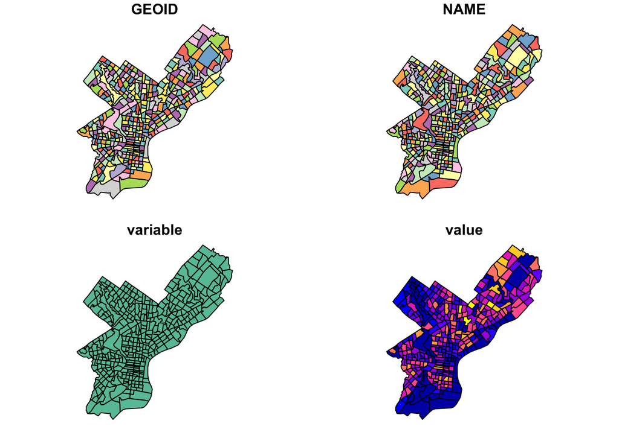

```r
plot(totalpop00)
```

### the textbook illustrates how to make progressively more useful maps using the ggplot function with geom_sf layers

from the textbook: A maps totalPop00, using the aes or aesthetic parameter to fill the tract polygons by the value field.

Plot B converts value to 5 quintile categories using the q5 function. These 5 categories are of class factor. Try q5(totalPop00$value).

Plot C adds fill color and legend improvements using the scale_fill_manual function. Many different scale types are possible.13 values is set to a list of colors, palette5. labels is set to the values of the associated quintiles (try qBr(totalPop00, “value”)). Finally, a legend name is added. inserts a hard return.

Plot D inserts a title using the labs parameter, as well as a mapTheme

```r
Plot_A <-
  ggplot() +
  geom_sf(data = totalpop00, aes(fill = value))

Plot_B <-
  ggplot() +
  geom_sf(data = totalpop00, aes(fill = q5(value)))

Plot_C <-
  ggplot() +
  geom_sf(data = totalpop00, aes(fill = q5(value))) +
  scale_fill_manual(values = palette5,
                    labels = qBr(totalpop00, "value"),
                    name = "Total\nPopluation\n(Quintile Breaks)")

Plot_D <-
  ggplot() +
  geom_sf(data = totalpop00, aes(fill = q5(value))) +
  scale_fill_manual(values = palette5,
                    labels = qBr(totalpop00, "value"),
                    name = "Popluation\n(Quintile Breaks)") +
  labs(title = "Total Population", subtitle = "Philadelphia; 2000") +
  mapTheme()
```

the above code saves our plots to their assigned variables. below we can print them.

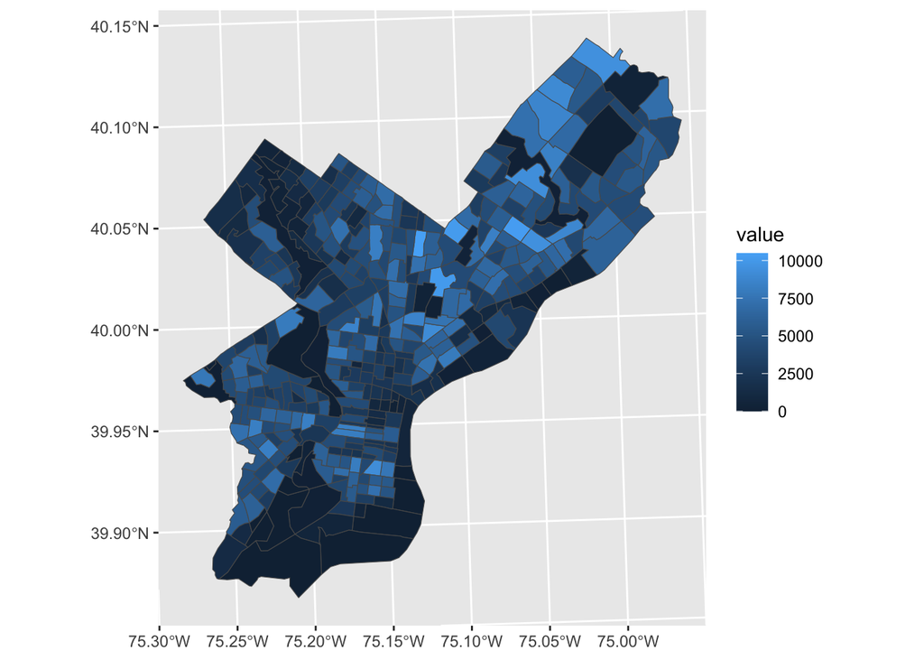

```r
print(Plot_A)
```

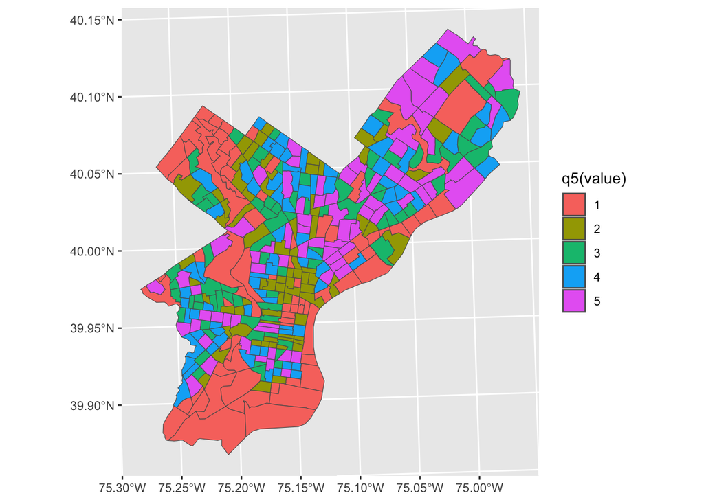

```r
print(Plot_B)
```

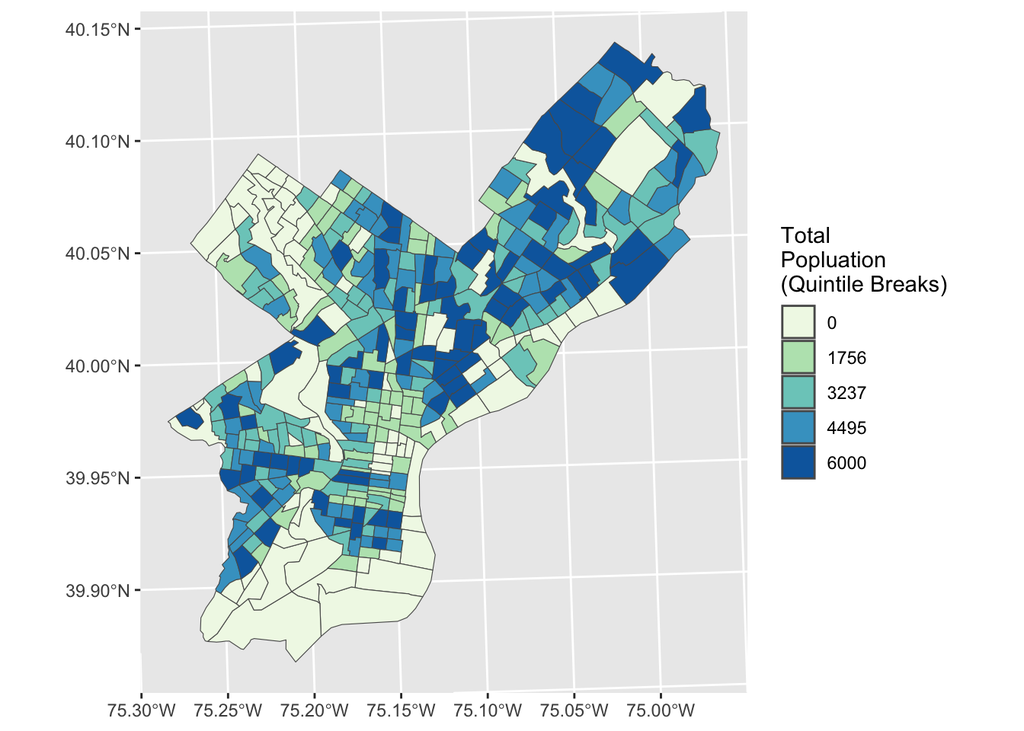

```r
print(Plot_C)
```

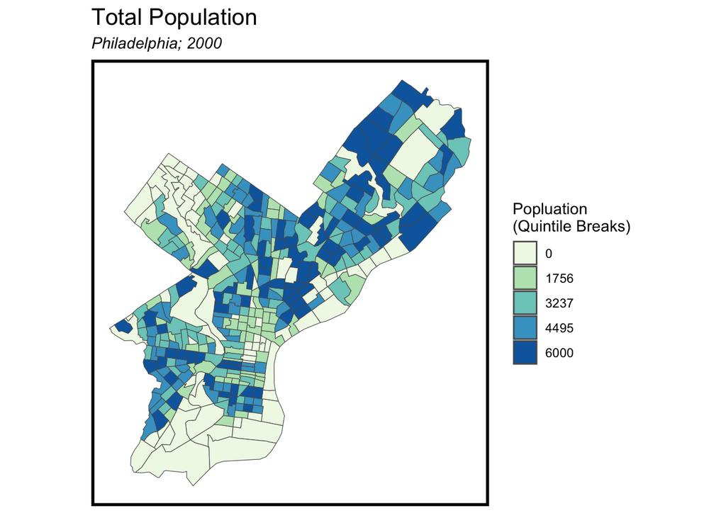

```r
print(Plot_D)
```

next, the textbook converts the data from long format to wide format and in general makes it easier to read.

```r
tracts00 <-
  dplyr::select(tracts00, -NAME) %>%
    spread(variable, value) %>%
    dplyr::select(-geometry) %>%
    rename(TotalPop = P001001, Whites = P006002, MaleBachelors = PCT025009,
           FemaleBachelors = PCT025050, MedHHInc = P053001, MedRent = H056001,
           TotalPoverty = P092001)

st_drop_geometry(tracts00)[1:3,]
```

```
##         GEOID MedRent TotalPop Whites MedHHInc TotalPoverty MaleBachelors
## 1 42101000100     858     2576   2095    48886         1739            64
## 2 42101000200     339     1355    176     8349          505            23
## 3 42101000300     660     2577   1893    40625         1189            41
##   FemaleBachelors
## 1              48
## 2              73
## 3             103
```

```r
tracts00 <-
  tracts00 %>%
  mutate(pctWhite = ifelse(TotalPop > 0, Whites / TotalPop, 0),
         pctBachelors = ifelse(TotalPop > 0, ((FemaleBachelors + MaleBachelors) / TotalPop), 0),
         pctPoverty = ifelse(TotalPop > 0, TotalPoverty / TotalPop, 0),
         year = "2000") %>%
  dplyr::select(-Whites,-FemaleBachelors,-MaleBachelors,-TotalPoverty)
```

now we are going to query 2017 acs data to match our 2000 data. I am going to change the code from the textbook so that we can see the data change which each line of code.

```r
tracts17 <-
  get_acs(geography = "tract", variables = c("B25026_001E","B02001_002E","B15001_050E",
                                             "B15001_009E","B19013_001E","B25058_001E",
                                             "B06012_002E"),
          year=2017, state=42, county=101, geometry=T, output="wide") %>%
    #the above code specifies the query from the census API, note that more than just the specified variables are generated as columns. I'm not sure what the additional variables represent.
    print() %>%
  st_transform('ESRI:102728') %>%
    # changes the CRS to what we have been using
    print() %>%
  rename(TotalPop = B25026_001E, Whites = B02001_002E,
         FemaleBachelors = B15001_050E, MaleBachelors = B15001_009E,
         MedHHInc = B19013_001E, MedRent = B25058_001E,
         TotalPoverty = B06012_002E) %>%
    #names our columns
    print() %>%
  dplyr::select(-NAME, -starts_with("B")) %>%
    #removes names and all the columns that start with "b". all the variable codes start with b, so any columns that we didnt name get deleted
    print() %>%
  mutate(pctWhite = ifelse(TotalPop > 0, Whites / TotalPop,0),
         pctBachelors = ifelse(TotalPop > 0, ((FemaleBachelors + MaleBachelors) / TotalPop),0),
         pctPoverty = ifelse(TotalPop > 0, TotalPoverty / TotalPop, 0),
         year = "2017") %>%
    #calculates our statistics of interest as a rate instead of a count. we use ifelse functions to account for cases in which we have 0 numerator or denominator. that could be a result of incomplete data.
    print() %>%
  dplyr::select(-Whites, -FemaleBachelors, -MaleBachelors, -TotalPoverty)
```

```
##
## Simple feature collection with 384 features and 16 fields
## Geometry type: MULTIPOLYGON
## Dimension:     XY
## Bounding box:  xmin: -75.28027 ymin: 39.86705 xmax: -74.95578 ymax: 40.13799
## Geodetic CRS:  NAD83
## First 10 features:
##          GEOID                                                  NAME
## 1  42101000200     Census Tract 2, Philadelphia County, Pennsylvania
## 2  42101000500     Census Tract 5, Philadelphia County, Pennsylvania
## 3  42101000901  Census Tract 9.01, Philadelphia County, Pennsylvania
## 4  42101001002 Census Tract 10.02, Philadelphia County, Pennsylvania
## 5  42101002000    Census Tract 20, Philadelphia County, Pennsylvania
## 6  42101003901 Census Tract 39.01, Philadelphia County, Pennsylvania
## 7  42101007102 Census Tract 71.02, Philadelphia County, Pennsylvania
```

[output cut: 203 more lines]

```r
    #removes the selected columns. the - operator specifies that we want everything besides the specified columns
head(tracts17)
```

```
## Simple feature collection with 6 features and 8 fields
## Geometry type: MULTIPOLYGON
## Dimension:     XY
## Bounding box:  xmin: 2686791 ymin: -79202.01 xmax: 2699682 ymax: -65257.88
## Projected CRS: NAD_1983_StatePlane_Pennsylvania_North_FIPS_3701_Feet
##         GEOID TotalPop MedHHInc MedRent  pctWhite pctBachelors pctPoverty year
## 1 42101000200     2479    30746    1051 0.2815651   0.10407422 0.38805970 2017
## 2 42101000500     1375    42135    1363 0.7970909   0.08436364 0.38981818 2017
## 3 42101000901     1949    42548    1095 0.7449974   0.06926629 0.24268856 2017
## 4 42101001002     3259   109020    1598 0.9377110   0.01258055 0.06474379 2017
## 5 42101002000     2154    41335     841 0.2479109   0.02089136 0.16945218 2017
## 6 42101003901     6583    38301     774 0.6983138   0.02491265 0.21616284 2017
##                         geometry
## 1 MULTIPOLYGON (((2694006 -65...
## 2 MULTIPOLYGON (((2693289 -66...
## 3 MULTIPOLYGON (((2693422 -69...
## 4 MULTIPOLYGON (((2697524 -70...
## 5 MULTIPOLYGON (((2686940 -72...
## 6 MULTIPOLYGON (((2690317 -78...
```

now we are going to combine our two data sets, one from 2000, one from 2017, together

```r
allTracts <- rbind(tracts00,tracts17)
```

## philly transit open data

from the textbook: The code below downloads and binds together El and Broad St. station locations into a single layer, septaStops. st_read downloads the data in geojson form (with geometries) from the web. A Line field is generated and selected along with the Station field. Lastly, the data is projected into the same coordinate system as tracts00.

```r
septaStops <-
  rbind(
    st_read("https://opendata.arcgis.com/datasets/8c6e2575c8ad46eb887e6bb35825e1a6_0.geojson") %>%
    mutate(Line = "El") %>% #this line adds the label 'El' to a newly created "Line" Column
    select(Station, Line),
      st_read("https://opendata.arcgis.com/datasets/2e9037fd5bef406488ffe5bb67d21312_0.geojson") %>%
      mutate(Line ="Broad_St") %>%
      select(Station, Line)) %>%
   st_transform(st_crs(tracts00))  #note how you can call the crs from the tracts00 dataframe using str_crs
```

lets map our stops onto the city

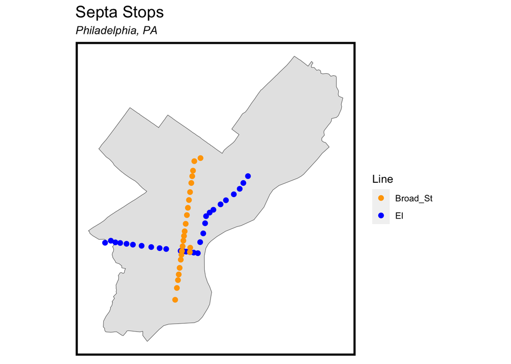

```r
ggplot() + #creates the plot
  geom_sf(data=st_union(tracts00)) + #adds the dissolved tract boundaries city map as a layer
  geom_sf(data=septaStops, aes(colour = Line), show.legend = "point", size= 2) + # adds the septaStops as a layer to the map with different colors for each of the values in the Line column
  scale_colour_manual(values = c("orange","blue")) +
  labs(title="Septa Stops", subtitle="Philadelphia, PA") +
  mapTheme()
```

now we are going to create “buffer” areas around each stop to be considered as transit oriented areas

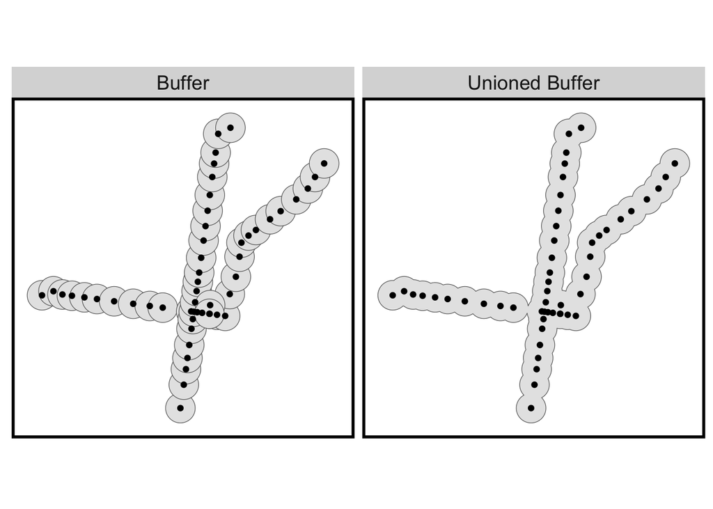

```r
septaBuffers <-
  rbind(
    st_buffer(septaStops, 2640) %>% # creates the buffers of 2640 feet (1/2 mile).
      mutate(Legend = "Buffer") %>% # creates legend column with a buffer label for each stop buffer
      dplyr::select(Legend), #selects only the legend column along with the geometry to remain in the dataframe
    st_union(st_buffer(septaStops, 2640)) %>%
      st_sf() %>% #this function is for some reason needed to convert the union transit areas created with the last line into an sf layer
      mutate(Legend = "Unioned Buffer"))

ggplot() +
  geom_sf(data=septaBuffers) +
  geom_sf(data=septaStops, show.legend = "point") +
  facet_wrap(~Legend) + #facet wrap can only be performed on long data
  mapTheme()
```

now we need to select which tracts constitute part of the trasit oriented area. there are three methods that the book discusses for selecting tracts. The first is clipping, which selects the interesections of the tract and the buffer. This is problematic because the data for each tract aligns with the whole tract and its unclear how the clipping method divides the other variables if at all after subtracting area.

```r
buffer <- filter(septaBuffers, Legend=="Unioned Buffer")

clip <-
  st_intersection(buffer, tracts00) %>%
    dplyr::select(TotalPop) %>%
    mutate(Selection_Type = "Clip")
```

the next method is to select any geometries that intersect with the buffer

```r
selection <-
  tracts00[buffer,] %>%
    dplyr::select(TotalPop) %>%
    mutate(Selection_Type = "Spatial Selection")
```

and the last method is to choose all tracts of which’s “center of gravity” fall within the buffer. you imigane the ceter of gravity as at what point you would need to put your finger to balance the shape atop of it. This is the preffered method of the author.

```r
selectCentroids <-
  st_centroid(tracts00)[buffer,] %>% #creates centroid point geometry for tracts whose centroid is within the buffer
print() %>%
    st_drop_geometry() %>% #this converts the sf into a dataframe to allow for it to be joined back with the original sf. I think that this is necessary because there cannot be more than one geometry per row in an sf
print() %>%
    left_join(dplyr::select(tracts00, GEOID)) %>% #this joins the two data frames by the unique geoids. so it seems that since our centroid frame is the first variable, we get only matches that exist from that frame. and what we are matching it to is only the GEOID from tracts00. since tracts is a sf it seems like you are unable to select away the geometry
print() %>%
    st_sf() %>% # converts dataframe back to sf
    dplyr::select(TotalPop) %>% #for some reason we only want total population
    mutate(Selection_Type = "Select by Centroids") #creates the select by centroids value in the Selection_type column. this will be useful for the side by side map we are going to create
```

```
## Simple feature collection with 97 features and 8 fields
## Geometry type: POINT
## Dimension:     XY
## Bounding box:  xmin: 2669191 ymin: -83405.65 xmax: 2716999 ymax: -34081.94
## Projected CRS: NAD_1983_StatePlane_Pennsylvania_North_FIPS_3701_Feet
## First 10 features:
##          GEOID MedRent TotalPop MedHHInc  pctWhite pctBachelors pctPoverty year
## 1  42101000100     858     2576    48886 0.8132764  0.043478261  0.6750776 2000
## 2  42101000200     339     1355     8349 0.1298893  0.070848708  0.3726937 2000
## 3  42101000300     660     2577    40625 0.7345751  0.055878929  0.4613892 2000
## 4  42101000400     601     4387    27400 0.7611124  0.028949168  0.6856622 2000
## 5  42101000500     501     1071     9620 0.3968254  0.006535948  0.2978525 2000
## 6  42101000600     913     1384    41563 0.7037572  0.067919075  0.4017341 2000
## 7  42101000700     844     2550    34536 0.8333333  0.075686275  0.7101961 2000
## 8  42101000800     904     8461    42346 0.8419809  0.066422409  0.7229642 2000
```

[output cut: 209 more lines]

```
##          GEOID MedRent TotalPop MedHHInc    pctWhite pctBachelors pctPoverty
## 1  42101000100     858     2576    48886 0.813276398 0.0434782609 0.67507764
## 2  42101000200     339     1355     8349 0.129889299 0.0708487085 0.37269373
## 3  42101000300     660     2577    40625 0.734575087 0.0558789290 0.46138921
## 4  42101000400     601     4387    27400 0.761112377 0.0289491680 0.68566218
## 5  42101000500     501     1071     9620 0.396825397 0.0065359477 0.29785247
## 6  42101000600     913     1384    41563 0.703757225 0.0679190751 0.40173410
## 7  42101000700     844     2550    34536 0.833333333 0.0756862745 0.71019608
## 8  42101000800     904     8461    42346 0.841980853 0.0664224087 0.72296419
## 9  42101000900     575     4969    20725 0.703763333 0.1465083518 0.64157778
## 10 42101001000     873     5808    72625 0.913395317 0.0110192837 0.62345041
## 11 42101001100     652     5925    36564 0.797468354 0.0494514768 0.65029536
## 12 42101001400     450     3528    26897 0.320011338 0.0229591837 0.52636054
## 13 42101001500     622     2192    38026 0.598540146 0.0369525547 0.53102190
## 14 42101001800     514     2462    36458 0.689277011 0.0170593014 0.51056052
```

[output cut: 181 more lines]

```r
print(selectCentroids)
```

```
## Simple feature collection with 97 features and 2 fields
## Geometry type: MULTIPOLYGON
## Dimension:     XY
## Bounding box:  xmin: 2667829 ymin: -84785.82 xmax: 2719496 ymax: -32044.96
## Projected CRS: NAD_1983_StatePlane_Pennsylvania_North_FIPS_3701_Feet
## First 10 features:
##    TotalPop                       geometry      Selection_Type
## 1      2576 MULTIPOLYGON (((2697812 -65... Select by Centroids
## 2      1355 MULTIPOLYGON (((2696038 -65... Select by Centroids
## 3      2577 MULTIPOLYGON (((2690929 -64... Select by Centroids
## 4      4387 MULTIPOLYGON (((2693009 -66... Select by Centroids
## 5      1071 MULTIPOLYGON (((2697206 -67... Select by Centroids
## 6      1384 MULTIPOLYGON (((2696968 -68... Select by Centroids
## 7      2550 MULTIPOLYGON (((2693753 -67... Select by Centroids
## 8      8461 MULTIPOLYGON (((2693685 -68... Select by Centroids
## 9      4969 MULTIPOLYGON (((2696756 -68... Select by Centroids
## 10     5808 MULTIPOLYGON (((2699725 -68... Select by Centroids
```

now the textbook challenges us to create a side by side maps of the various selection types using the facet_wrap layer tool from earlier

```r
all_types_tracts00 <-
    rbind(clip,selection,selectCentroids)
```

imma set the size of the output. wasnt happy with the default

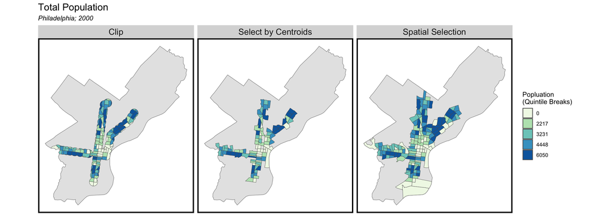

```r
ggplot() + #creates the plot
  geom_sf(data=st_union(tracts00)) + #creates our city outline
     geom_sf(data = all_types_tracts00, aes(fill = q5(TotalPop))) +
  scale_fill_manual(values = palette5,
                    labels = qBr(all_types_tracts00, "TotalPop"),
                    name = "Popluation\n(Quintile Breaks)") +
  labs(title = "Total Population", subtitle = "Philadelphia; 2000") +
facet_wrap(~Selection_Type) +
  mapTheme()
```

the below code redoes our centroid approach and labels those tracts whose centroid falls into the buffer as transit oriented development. It label those tracts that do not fall into the buffer as non TOD.

```r
allTracts.group <-
  rbind( #since left join takes the first argument as the total number of rows, we need to bind the two subsets of the full datset on to of each other.
    st_centroid(allTracts)[buffer,] %>% #selects the tracts whose centroids fall in the buffer
      st_drop_geometry() %>% # drops the geometry to allow easier manipulation as a dataframe or maybe you just cant have two geometries per sf
      left_join(allTracts) %>% #joins the missing data in our centroid tract data to the data from allTracts. this command outomatically matches columns to prevent duplication
      st_sf() %>% #converts that data to an sf
      mutate(TOD = "TOD"), #creates the TOD column and labels all the current data as TOD, not the comma. everything this line and above is the first argument of rbind
    st_centroid(allTracts)[buffer, op = st_disjoint] %>% # the disjoint option basically inverses the command so that we select all tracts that are not in buffer
      st_drop_geometry() %>%
      left_join(allTracts) %>%
      st_sf() %>%
      mutate(TOD = "Non-TOD")) %>% #labels every tract not in the buffer as non TOD
  mutate(MedRent.inf = ifelse(year == "2000", MedRent * 1.42, MedRent)) # multiplies all the year 2000 rents by inflation
```

[output not shown]

[output not shown]